# House prices

2022-06-17

# Introduction

This notebook is for the prediction of property sale price. This notebook will be split into four major sections.

1. processing missing analysis
2. exploratory analysis, e.g. correlation plots
3. feature engineering
4. modeling

My initial thoughts based on a glimpse at the data is to predict sale price using the general features of quality, size, and location. The time may also play a role in the sale of a home but given my limited time working on this problem I will not prioritize time series.

# Importing

```r
devtools::load_all()
x <- list(
"magrittr",
"tidyverse",
"purrr",
"rcompanion",
"naniar",
"caret", # for dummy and one hot encode
"glmnet",
"plotmo",
"corrr",
"corrplot")
lapply(x, require, character.only = TRUE)
```

[output not shown]

```r
# IMPORTING
# Import training and test data, which we will soon combine, as we want to process explanatory variables together
dftrain <- read.csv(here::here("data-raw", "train.csv")) %>% dplyr::mutate(set = "train")
dftest <- read.csv(here::here("data-raw", "test.csv")) %>% dplyr::mutate(set = "test") %>% dplyr::mutate(SalePrice = NA)
df <- dplyr::bind_rows(dftrain, dftest)
```

# Processing and missing analysis

First we take a glimpse and see if we can fix any errors. Columns with extremely high values of NAs will be removed. We may be able to infer categories from the missing values. Later in analysis, we may want to reconsider miss_case_summary() which gives us percentage of missing variables in a row. If a row has a large percentage of data missing it may be better to exclude than to impute.

```r
df %>%
  naniar::miss_var_summary() %>%
  dplyr::filter(pct_miss > 0) %>%
  print(n=Inf)
```

```
## # A tibble: 35 x 3
##    variable     n_miss pct_miss
##    <chr>         <int>    <dbl>
##  1 PoolQC         2909  99.7
##  2 MiscFeature    2814  96.4
##  3 Alley          2721  93.2
##  4 Fence          2348  80.4
##  5 SalePrice      1459  50.0
##  6 FireplaceQu    1420  48.6
##  7 LotFrontage     486  16.6
##  8 GarageYrBlt     159   5.45
##  9 GarageFinish    159   5.45
## 10 GarageQual      159   5.45
## 11 GarageCond      159   5.45
## 12 GarageType      157   5.38
```

[output cut: 23 more lines]

Firstly, lets remove variables which have such a high percentage of NA that they are not of use, even with correctly imputed values.

We know from the data description the NAs are categorical for not-applicable. For catagorical variables we will create this level. For numeric variables we will impute with zero. In the case of the garage year, we impute with the year the home was built. This is not ideal as there is likely no garage. Other options include creating a variable for “no_garage” or excluding the garage year variable. We may circle back to this.

```r
# PoolQC and MiscFeatures are too heavily not-applicable and will not be useful
df <- df %>%
  dplyr::select(-c("PoolQC", "MiscFeature"))

vars_missing <- df %>%
  naniar::miss_var_summary() %>%
  dplyr::filter(pct_miss > 0) %>%
  dplyr::pull(variable)
charvars <- names(df)[sapply(df, class) == 'character']
char_vars_missing <- vars_missing[vars_missing %in% charvars]
num_vars_missing <- vars_missing[!vars_missing %in% c(charvars, "SalePrice")]
# Impute NAs with "not-appl"
df <- df %>%
  dplyr::mutate_at(char_vars_missing, ~tidyr::replace_na(., "not-appl"))  %>%
  dplyr::mutate_at(num_vars_missing, ~tidyr::replace_na(., 0)) %>%
  dplyr::mutate(GarageYrBlt = ifelse(GarageYrBlt == 0, YearBuilt, GarageYrBlt)) #custom replacement for garrageyrblt
```

Let’s also remove a few more variables which don’t contain enough information and factor non-ordinal categories

```r
# removing some vars that are entirely one group
df <- df %>%
  dplyr::select(-c("Street", "Utilities", "RoofMatl", "Heating"))
```

# Exploratory data analysis

## Glimpse at the response variable (sale price)

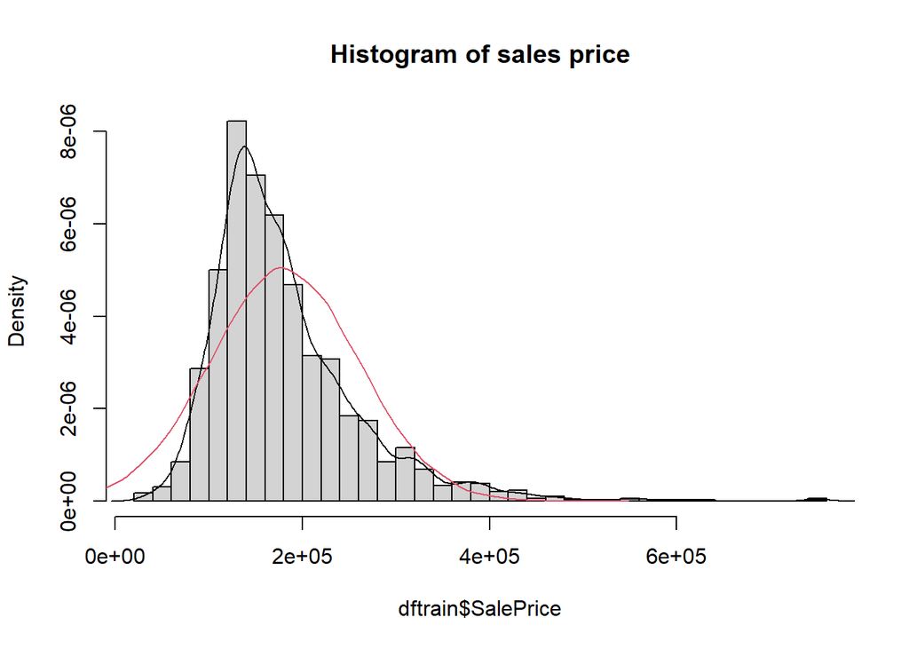

```r
# RESPONSE VARIABLE (move this past processing to EDA)
# check dist of response var is statistically different from normal
hist(dftrain$SalePrice,probability=T, main="Histogram of sales price", 50)
norm <- rnorm(100000, mean(dftrain$SalePrice), sd(dftrain$SalePrice))
lines(density(dftrain$SalePrice), col=1)
lines(density(norm),col=2)
```

```r
# pointy dist with heavy tail on the right
shapiro.test(dftrain$SalePrice)
```

```
##
##  Shapiro-Wilk normality test
##
## data:  dftrain$SalePrice
## W = 0.86967, p-value < 2.2e-16
```

Sales price has a heavy right tail and a pointy distribution (black line). Based on the shapiro test it is significantly different from a normal distribution. We log scale to obtain a more normal distribution.

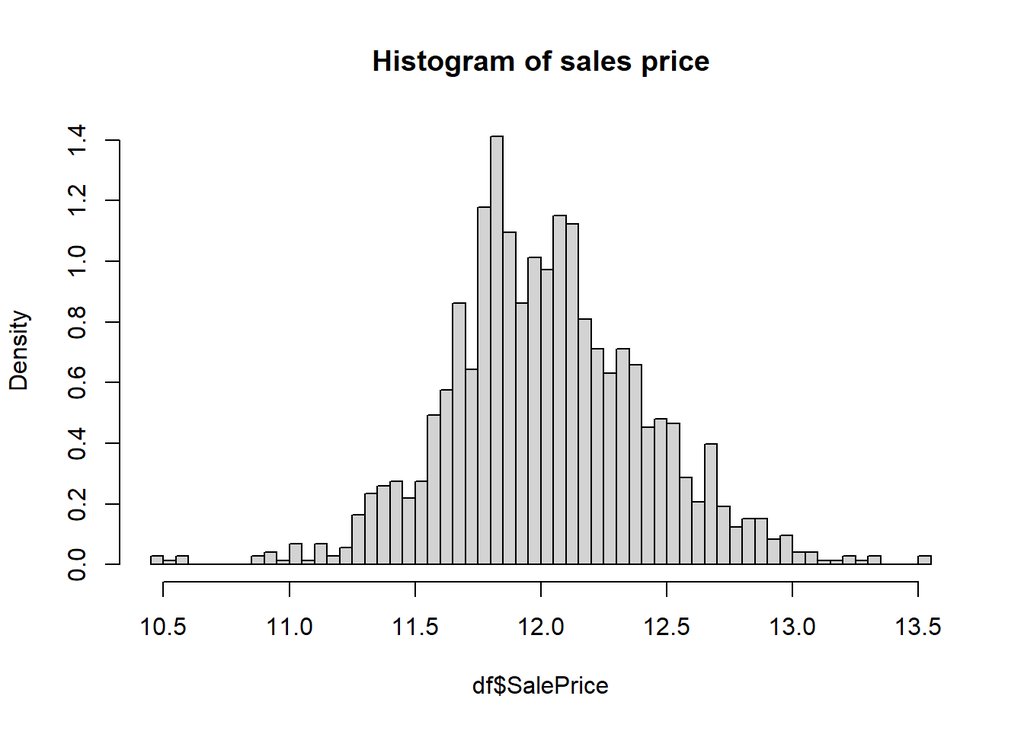

```r
df <- df %>%
  dplyr::mutate(SalePrice = log(SalePrice))
hist(df$SalePrice,probability=T, main="Histogram of sales price", 50)
```

## Correlation

Now that we have done some of our cleaning complete we can take a look at correlation plots. I’m going to separate nominal and numeric for most of this section for plot readability and for the following sections which handle these data types differently.

```r
charvars <- names(df)[sapply(df, class) == 'character']
dftemp <- df %>%
  dplyr::mutate_at(charvars, as.factor) %>%
  dplyr::mutate(MSSubClass = as.factor(MSSubClass))


nom_vars <- names(dftemp)[sapply(dftemp, class) == 'factor']
num_ord_vars <- names(dftemp)[!names(dftemp) %in% nom_vars]

tempnom <- dftemp %>%
  dplyr::select(c("SalePrice", nom_vars)) %>% # including sale price with ordinal as well
  dplyr::select(-set) %>%
  mixed_assoc() %>%
  dplyr::select(x, y, assoc) %>%
  tidyr::spread(y, assoc) %>%
  tibble::column_to_rownames("x")
```

```
## Note: Using an external vector in selections is ambiguous.
## i Use `all_of(nom_vars)` instead of `nom_vars` to silence this message.
## i See <https://tidyselect.r-lib.org/reference/faq-external-vector.html>.
```

```r
tempnum <- dftemp %>%
  dplyr::select(c("SalePrice", num_ord_vars)) %>% # including sale price with ordinal as well
  mixed_assoc() %>%
  dplyr::select(x, y, assoc) %>%
  tidyr::spread(y, assoc) %>%
  tibble::column_to_rownames("x")
```

```
## Note: Using an external vector in selections is ambiguous.
## i Use `all_of(num_ord_vars)` instead of `num_ord_vars` to silence this message.
## i See <https://tidyselect.r-lib.org/reference/faq-external-vector.html>.
```

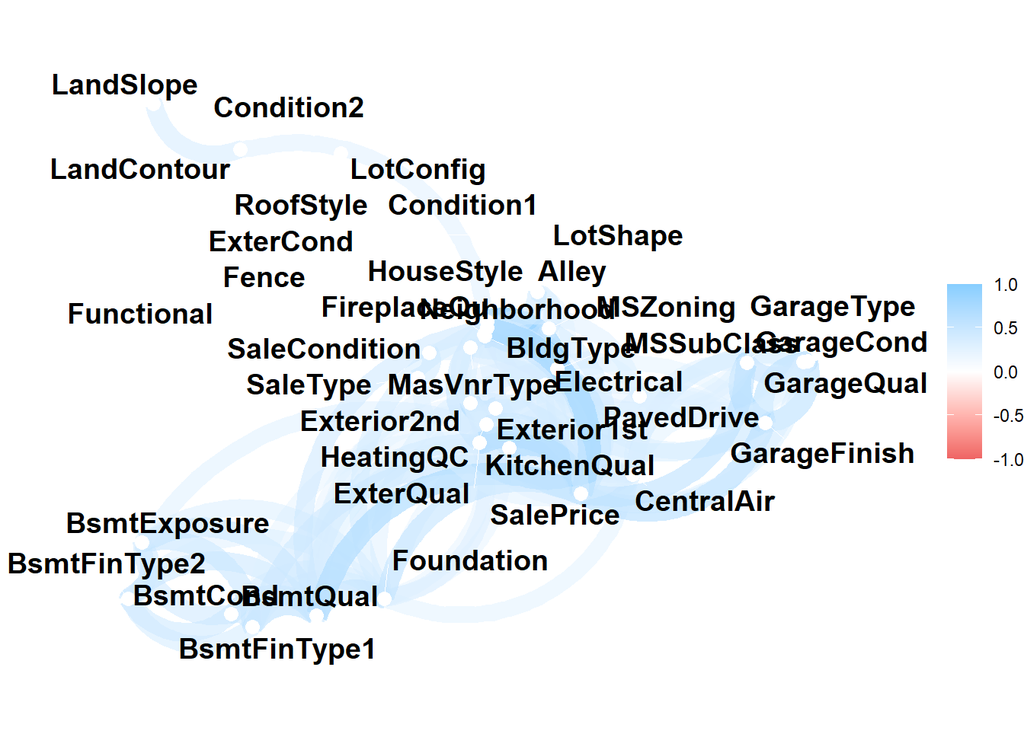

```r
temp <- dftemp %>%
  dplyr::select(c("SalePrice", num_ord_vars, nom_vars)) %>% # including sale price with ordinal as well
  dplyr::select(-set) %>%
  mixed_assoc() %>%
  dplyr::select(x, y, assoc) %>%
  tidyr::spread(y, assoc) %>%
  tibble::column_to_rownames("x")

# allowing for all overlap text
options(ggrepel.max.overlaps = Inf)

tempnom %>%
  as.matrix %>%
  corrr::as_cordf() %>%
  corrr::network_plot(min_cor = 0.3)
```

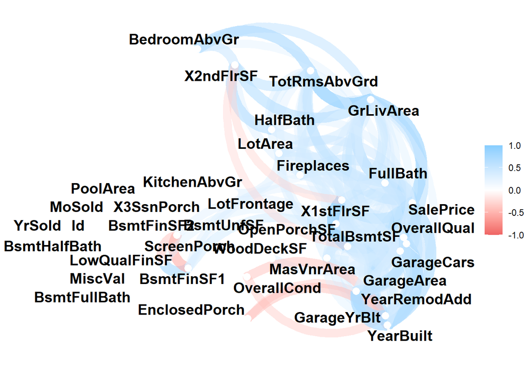

```r
# corrplot::corrplot(tempnom %>% as.matrix %>% .[dim(tempnom)[1]:1,dim(tempnom)[1]:1], method = 'square', order = 'FPC', type = 'lower', diag = TRUE, tl.col = "black", tl.cex=.75)

tempnum %>%
  as.matrix %>%
  corrr::as_cordf() %>%
  corrr::network_plot(min_cor = 0.3)
```

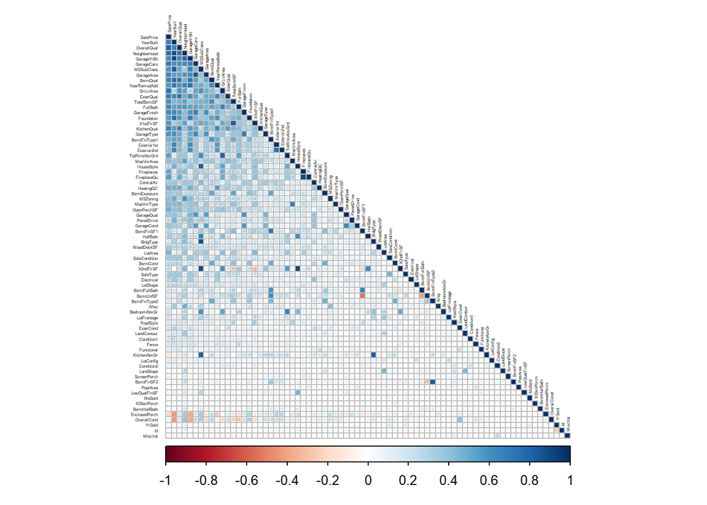

```r
corrplot::corrplot(temp %>% as.matrix %>% .[dim(temp)[1]:1,dim(temp)[1]:1], method = 'square', order = 'FPC', type = 'lower', diag = TRUE, tl.col = "black", tl.cex=.25)
```

## Correlation plot

### Numeric(continuous and ordinal) variables

The number of variables describing the size and quality is very high. There is a great amount of corelation within these variables.

### Mixed association heatmap

The heatmap displays both numeric and nominal variables together. There are several variables which are highly correlated with each other e.g. garage and year built, MSSubClass and year built, etc. Niche item like features such as screened porches, pools, fences, etc, do not seem to be very correlated with the outcome.

## Select plots of highly correlated variables

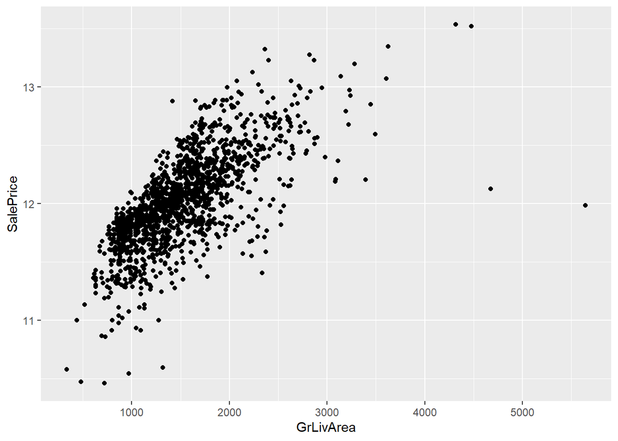

```r
library(ggplot2)
ggplot(df) +
  geom_point(aes(x = GrLivArea, y = SalePrice))
```

We see two clear outliers on the right hand side beyond 4500. I imagine these may be older homes or commercial properties. Otherwise, it may be an oddity in the calculation of GrLivArea (in which calculation is unknown).

```r
df %>%
  dplyr::filter(GrLivArea > 4500) %>%
  dplyr::select(GrLivArea, YearBuilt, OverallQual, SaleType, MSZoning, TotalBsmtSF, set)
```

```
##   GrLivArea YearBuilt OverallQual SaleType MSZoning TotalBsmtSF   set
## 1      4676      2007          10      New       RL        3138 train
## 2      5642      2008          10      New       RL        6110 train
## 3      5095      2008          10      New       RL        5095  test
```

```r
df <- df %>%
  dplyr::filter(!(GrLivArea > 4500 & set == "train"))
```

They are not old or commercial properties. The square footage (SF) seems to be erroneous. I am unable to determine if other information in these rows is erroneous so I chose to remove the rows.

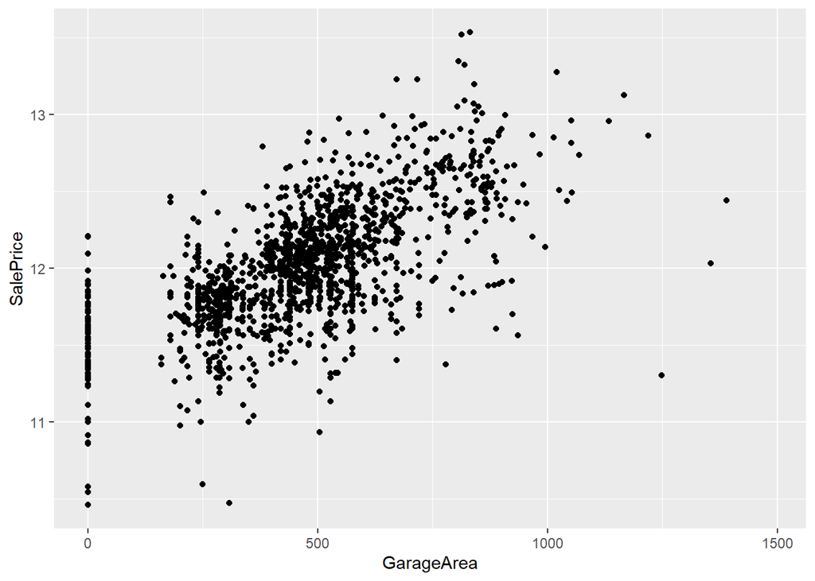

```r
ggplot(df) +
  geom_point(aes(x = GarageArea, y = SalePrice))
```

A few outliers on the right and side. I don’t suspect they are erroneous and I will leave these rows. The zeros are for houses without garage.

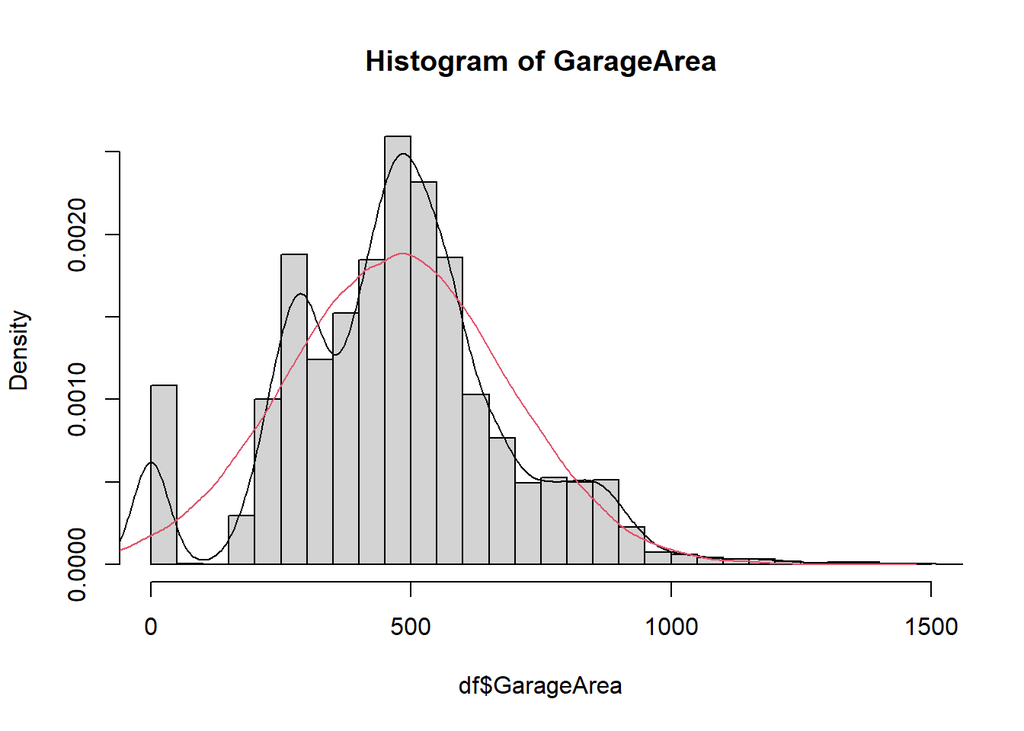

```r
hist(df$GarageArea,probability=T, main="Histogram of GarageArea", 50)
norm <- rnorm(100000, mean(df$GarageArea), sd(df$GarageArea))
lines(density(df$GarageArea), col=1)
lines(density(norm),col=2)
```

```r
shapiro.test(df$GarageArea)
```

```
##
##  Shapiro-Wilk normality test
##
## data:  df$GarageArea
## W = 0.97649, p-value < 2.2e-16
```

This distribution is not normal for a few reasons (zeros, multiple peaks, skewness). The multiple peaks which is intuitive as there are 1,2,3 car garage sizes. If we were to bin this variable to may be too correlated with the variable that describes the number of cars the garage fits.

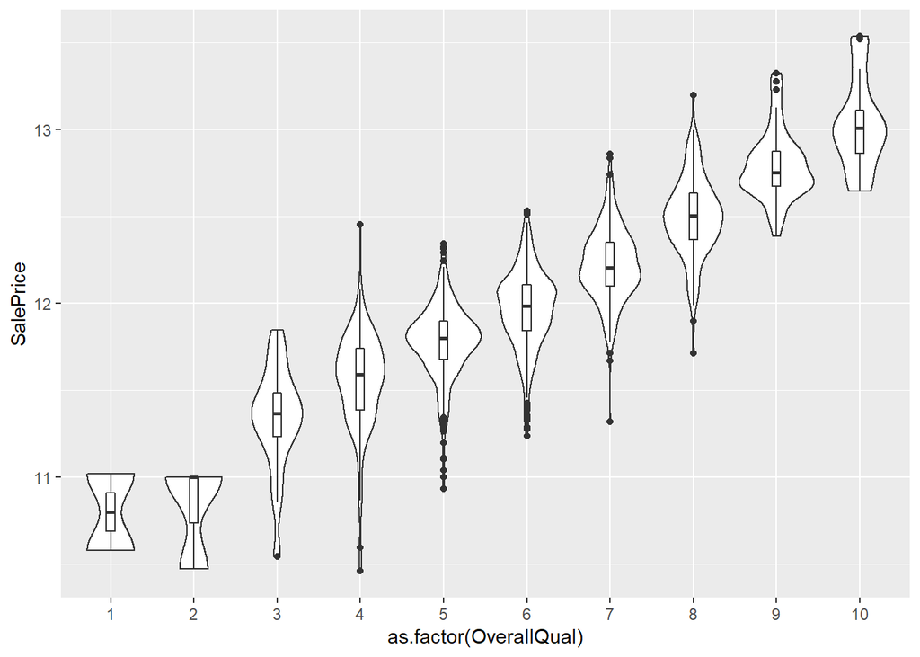

```r
ggplot(df, aes(x=as.factor(OverallQual), y=SalePrice)) +
  geom_violin() +
  geom_boxplot(width=0.1)
```

## Sparse modeling

Gertheiss and Tutz 2010

This paper presents Lasso-like solution paths that show how levels of two categorical variables get merged together when regularization strength increases. I wont be using weights as suggested in the paper but borrowing the general concept.

For sparse categorical data we will collapse them into fewer groupings. One hot encoding is used for LASSO.

```r
nomvars <- names(df)[sapply(df, class) == 'factor']
temp <- df %>%
  dplyr::select(nomvars)
```

```
## Note: Using an external vector in selections is ambiguous.
## i Use `all_of(nomvars)` instead of `nomvars` to silence this message.
## i See <https://tidyselect.r-lib.org/reference/faq-external-vector.html>.
```

```r
summary(temp)
```

```
## < table of extent 0 x 0 >
```

The following variables caught my eye in terms of usefulness from correlation, and in terms of having too many/too small categories.

```r
nomvars_of_interest <- c(
"Neighborhood",
"MSZoning",
"SaleCondition",
"BsmtExposure",
"KitchenQual",
"GarageType",
"PavedDrive")


df2 <- df %>%
  dplyr::select(c(nomvars_of_interest, "set")) %>%
  dplyr::mutate_at(nomvars_of_interest, as.factor) %>%
  dplyr::filter(set == "train") %>%
  dplyr::select(-set)
```

```
## Note: Using an external vector in selections is ambiguous.
## i Use `all_of(nomvars_of_interest)` instead of `nomvars_of_interest` to silence this message.
## i See <https://tidyselect.r-lib.org/reference/faq-external-vector.html>.
```

```
##  [1] "Neighborhood.Blmngtn" "Neighborhood.Blueste" "Neighborhood.BrDale"
##  [4] "Neighborhood.BrkSide" "Neighborhood.ClearCr" "Neighborhood.CollgCr"
##  [7] "Neighborhood.Crawfor" "Neighborhood.Edwards" "Neighborhood.Gilbert"
## [10] "Neighborhood.IDOTRR"  "Neighborhood.MeadowV" "Neighborhood.Mitchel"
## [13] "Neighborhood.NAmes"   "Neighborhood.NoRidge" "Neighborhood.NPkVill"
## [16] "Neighborhood.NridgHt" "Neighborhood.NWAmes"  "Neighborhood.OldTown"
## [19] "Neighborhood.Sawyer"  "Neighborhood.SawyerW" "Neighborhood.Somerst"
## [22] "Neighborhood.StoneBr" "Neighborhood.SWISU"   "Neighborhood.Timber"
## [25] "Neighborhood.Veenker"
```

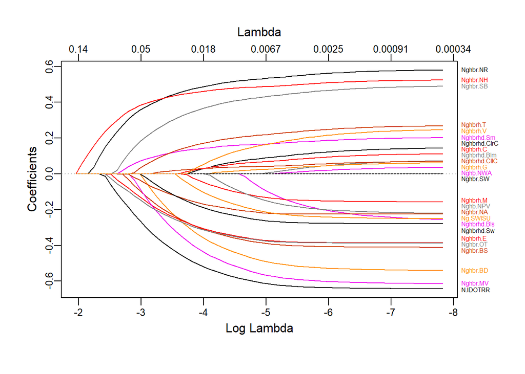

```
## [1] "MSZoning.C..all."  "MSZoning.FV"       "MSZoning.not.appl"
## [4] "MSZoning.RH"       "MSZoning.RL"       "MSZoning.RM"
```

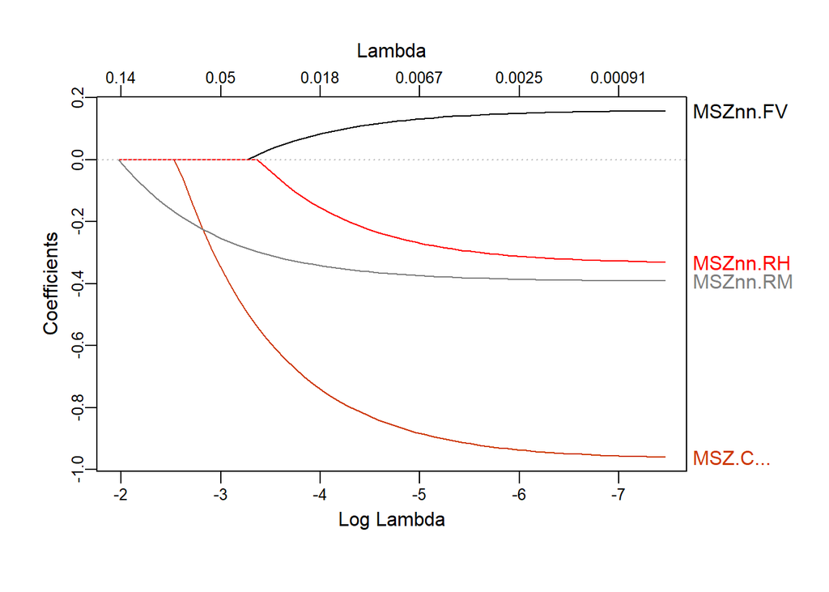

```
## [1] "SaleCondition.Abnorml" "SaleCondition.AdjLand" "SaleCondition.Alloca"
## [4] "SaleCondition.Family"  "SaleCondition.Normal"  "SaleCondition.Partial"
```

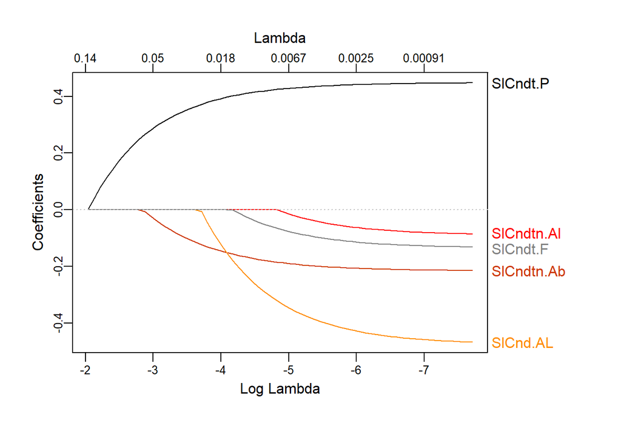

```
## [1] "BsmtExposure.Av"       "BsmtExposure.Gd"       "BsmtExposure.Mn"
## [4] "BsmtExposure.No"       "BsmtExposure.not.appl"
```

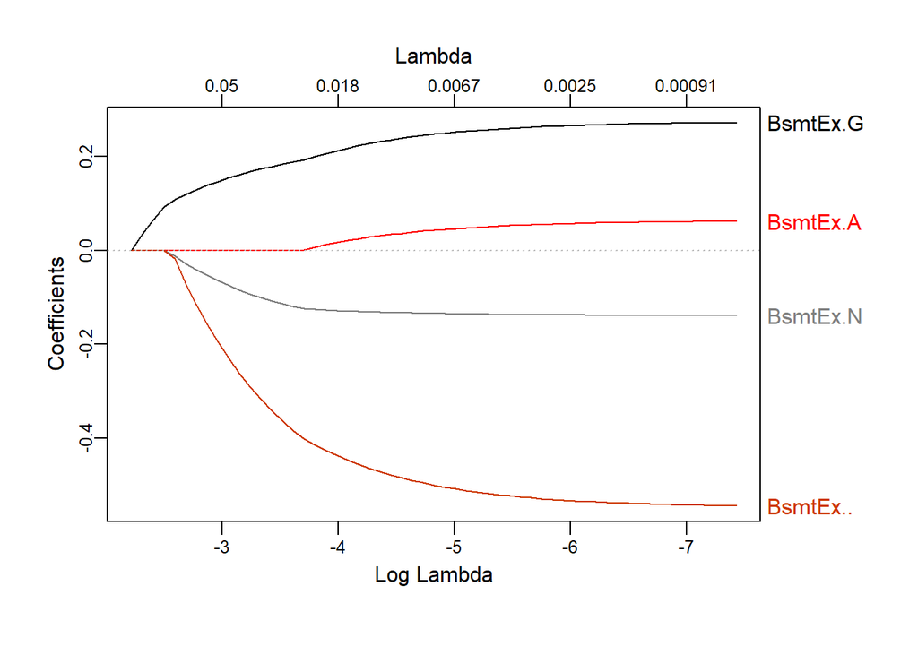

```
## [1] "KitchenQual.Ex"       "KitchenQual.Fa"       "KitchenQual.Gd"
## [4] "KitchenQual.not.appl" "KitchenQual.TA"
```

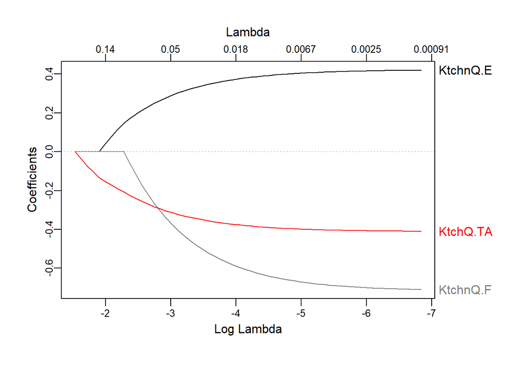

```
## [1] "GarageType.2Types"   "GarageType.Attchd"   "GarageType.Basment"
## [4] "GarageType.BuiltIn"  "GarageType.CarPort"  "GarageType.Detchd"
## [7] "GarageType.not.appl"
```

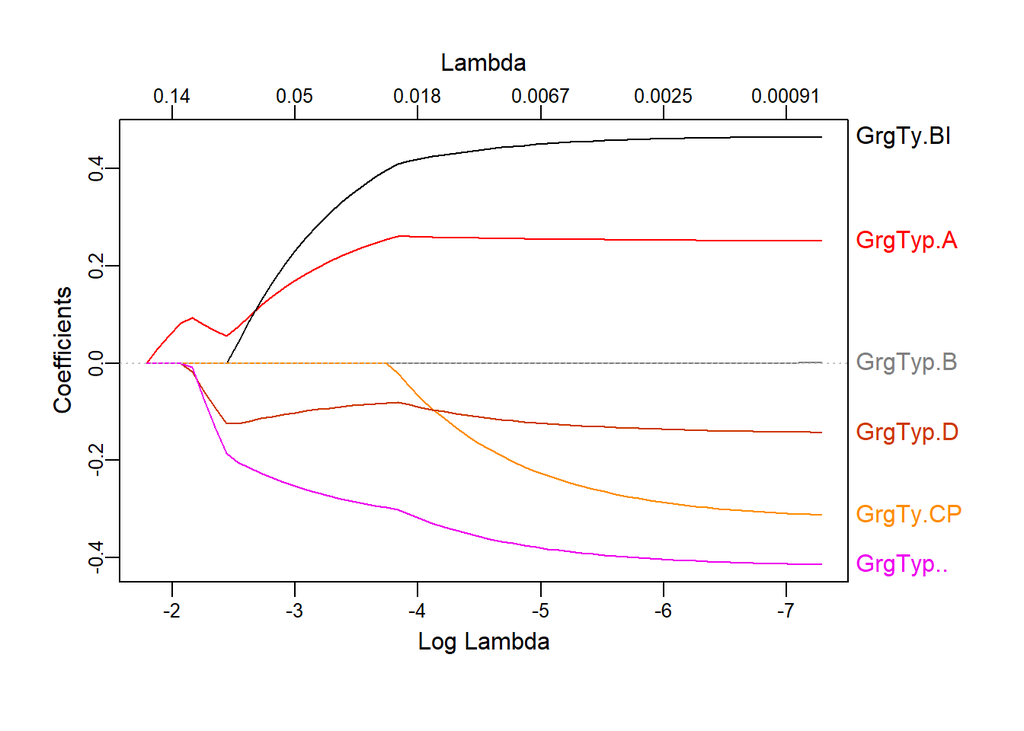

```
## [1] "PavedDrive.N" "PavedDrive.P" "PavedDrive.Y"
```

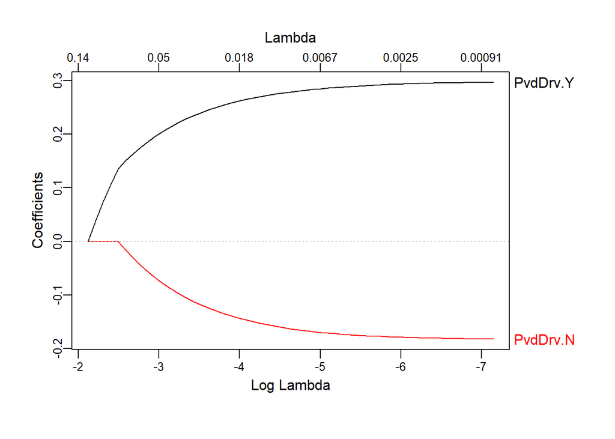

```r
library(caret)
dummy <- dummyVars(" ~ .", data=df2)
df3 <- data.frame(predict(dummy, newdata = df2))
y <- df %>%
  dplyr::filter(set == "train") %>%
  dplyr::pull(SalePrice)


library(glmnet)
library(plotmo)
# Lets do individual lasso instead
# Can we figure out weights from munic real estate paper?
for (name in names(df2)) {
dftemp <- df3 %>% dplyr::select(dplyr::starts_with(name))
print(df3 %>% dplyr::select(dplyr::starts_with(name)) %>% colnames)
fit <- glmnet(dftemp, y = y, alpha = 1) #alpha 1 is lasso, 0 is ridge
plot_glmnet(fit, label=TRUE)
}
```

## Sparse modeling (continued)

1. MSZoning This variable is difficult to collapse due to unusual types of location such as floating villages which do not bin well in terms being similar. This may not work.
2. Neighborhood_bigbin Collapsing using LASSO groups.
3. Neighborhood This is a hack (ideally should do something else) such that we have enough unique values within group to use quantile in feature engineering.
4. BsmtQual Collapsing some of the smaller categories.
5. BsmtExposure Collapsing into an indicator.
6. GarageTypeCollapsing some of the smaller categories.
7. KitchenQual Collapsing some of the smaller categories.
8. SaleCondition Collapsing to norm, abnorm, and partial, other categories coefs get zeroed out early / not enough data

```r
df <- df %>%
  dplyr::mutate(MSZoning = ifelse(MSZoning %in% c("RH","C (all)", "FV", "not-appl", "RM"), "RM", "RL")) %>%
  dplyr::mutate(Neighborhood_bigbin = ifelse(Neighborhood %in% c("NoRidge", "NridgHt", "StoneBr"), "top",
                                       ifelse(Neighborhood %in% c("IDOTRR", "MeadowV", "BrDale"), "bottom",
                                              ifelse(Neighborhood %in% c("BrkSide", "OldTown", "Edwards", "Sawyer", "Blueste", "SWISU","NAmes", "NPkVill", "Mitchel"), "midlow",
                                                     ifelse(Neighborhood %in% c("NWAmes", "Gilbert", "CollgCr", "Blmngtn", "Crawfor", "ClearCr","Somerst", "Veenker", "Timber", "SawyerW"), "midupp", NA))))) %>% #ideally we would have spatial or hierarchical model for these groups
   dplyr::mutate(Neighborhood = ifelse(Neighborhood %in% c("BrDale", "IDOTRR"), "MeadowV", Neighborhood)) %>% #small hack for later feature that requires more samples
  dplyr::mutate(BsmtQual = ifelse(BsmtQual %in% c("TA", "not-appl", "Fa"), 0,
                                  ifelse(BsmtQual %in% c("Gd"), 1,
                                         ifelse(BsmtQual %in% c("Ex"), 2, NA)))) %>%
  dplyr::mutate(GarageType = ifelse(GarageType %in% c("BuiltIn", "Attchd"), 1, 0)) %>%
  dplyr::mutate(BsmtExposure = ifelse(BsmtExposure == "Gd", 1, 0)) %>%
  dplyr::mutate(KitchenQual = ifelse(KitchenQual == "Ex", "Ex",
                                     ifelse(KitchenQual == "Gd", "Gd", "NW"))) %>%
  dplyr::mutate(SaleCondition = ifelse(SaleCondition == "Normal", "Normal",
                                       ifelse(SaleCondition == "Partial", "Partial", "Abnorml")))


# collapsing some more straight forward vars based on data definitions
df <- df %>%
  dplyr::mutate(PavedDrive = ifelse(PavedDrive == "P", "N", PavedDrive)) %>%
  dplyr::mutate(has_fireplace = ifelse(Fireplaces == 0, 0, 1))
```

# Feature engineering

## Homogeneous neighborhood condition

My wife was watching and convinced me to make this one :) The idea here is that in a wealthy neighborhood, all of the homes should be in good condition. i.e. little variability in the nearby home condition.

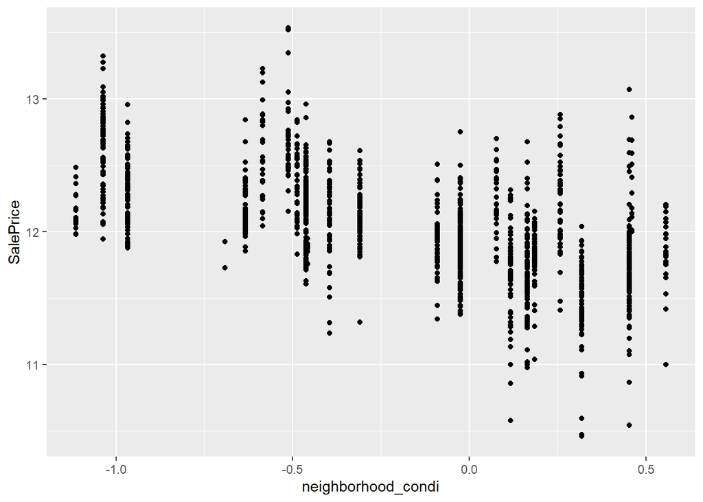

```r
sdcondi <- sd(df$OverallCond)
df <- df %>%
  dplyr::group_by(Neighborhood) %>%
  dplyr::mutate(neighborhood_condi = sd(OverallCond) - sdcondi) %>%
  dplyr::mutate(neighborhood_condi_ind = ifelse(neighborhood_condi < -.8, 1,0)) %>%
  dplyr::ungroup()

ggplot(df) +
  geom_point(aes(x = neighborhood_condi, y = SalePrice))
```

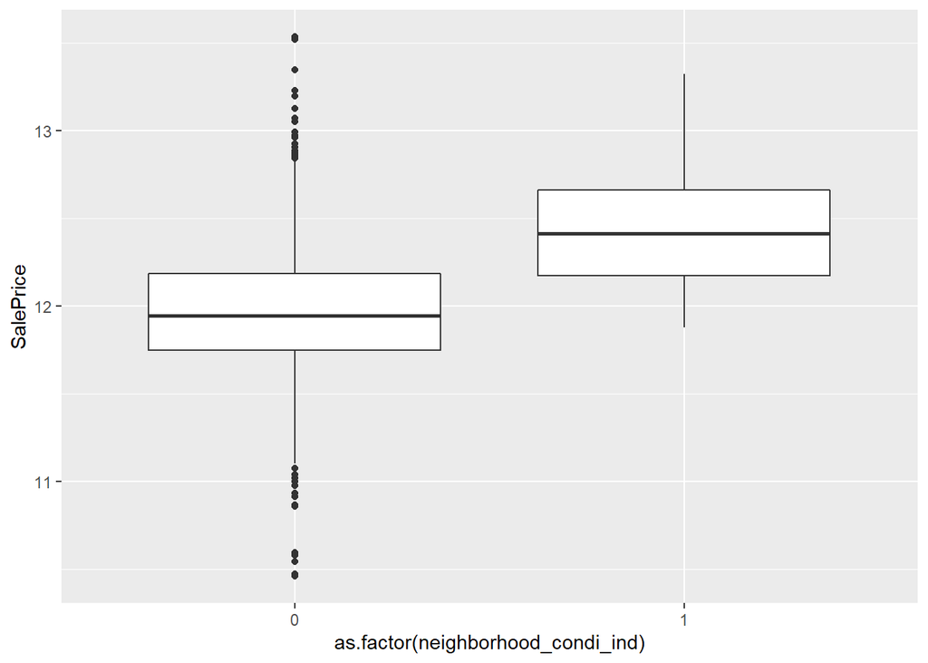

```r
ggplot(df) +
  geom_boxplot(aes(x = as.factor(neighborhood_condi_ind), y = SalePrice))
```

## Age and year

Let’s obtain how recently home was built / remodeled as those provide different information from the year. The year/ month can provide time series information and categorized year could provide information on home style (e.g. mid century modern homes built 1950-1969) but we will leave for that another time. Since we are limited on time, let’s also obtain a simple season indicator which is more simple than time series.

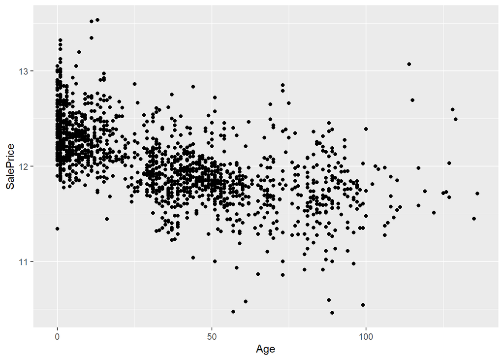

```r
df <- df %>%
  dplyr::mutate(Age = YrSold-YearBuilt) %>%
  dplyr::mutate(AgeOfRemodel = YrSold-YearRemodAdd) %>%
  dplyr::mutate(SeasonalSell = ifelse(MoSold %in% c(3,4,5,6,7,8), 1,0))
ggplot(df) +
  geom_point(aes(x = Age, y = SalePrice))
```

## Liveable square feet (SF)

I want to improve upon the square footage variables of the home (similar to the idea behind the given above ground SF variable). As a home buyer myself, I find listed square footage essential but often misleading as it can refer to basement square footage (SF), or poorly utilized SF. Basement SF is the most misleading so it will be my focus here. Since we have square footage breakdown we can sum them in a custom way to create a heuristic total square footage we will call this `LiveableModSF`.

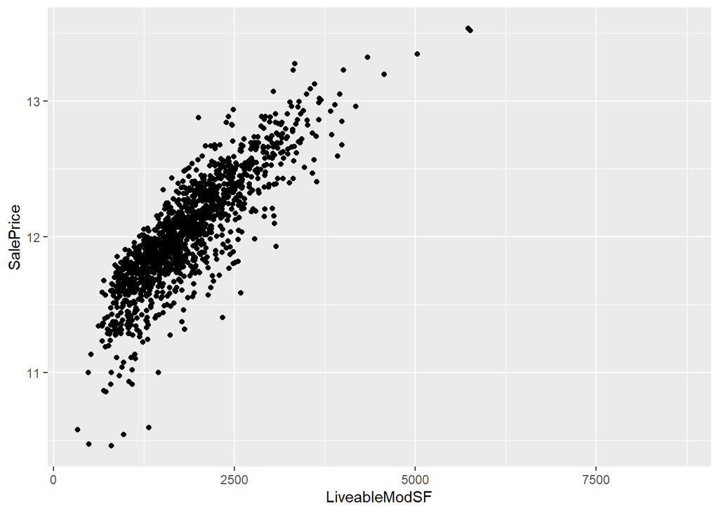

```r
# # here is an example which breaks down my heuristic factors (essentially I wanted to basement SF to have a varying heuristic multiplier which max out around 1 such that above ground SF is more valuable. Utilizing basement bathrooms to show value in realization of basement as an addition floor to the house)
# BsmtFullBath <- c(0,1,2,3)
# BsmtHalfBath <- c(0,1,2,1)
# BsmtQual <- c(0,.1,.1,.2)
# BsmtExposure <- c(1,1,1,1)
# bbath1 <- log(BsmtFullBath+2)*.3
# bbath2 <- log(BsmtHalfBath+2)*.15
# (((bbath1 + bbath2)/2)+BsmtQual+.3*BsmtExposure)#*BsmtFinSF1


df <- df %>%
  dplyr::mutate(LiveableModSF = (((log(BsmtFullBath+2)*.3 + log(BsmtHalfBath+2)*.15)/2)+(BsmtQual/10)+.3*BsmtExposure)*BsmtFinSF1 + X1stFlrSF + X2ndFlrSF + GarageType*GarageArea*.5) #garage SF gets zeroed if not attached to the house. attached garage makes home look bigger, feel bigger, curb appeal, etc
ggplot(df) +
  geom_point(aes(x = LiveableModSF, y = SalePrice))
```

## Open floor plan

Going a step further with total SF, let’s see if we can proxy for homes with open floor plans.

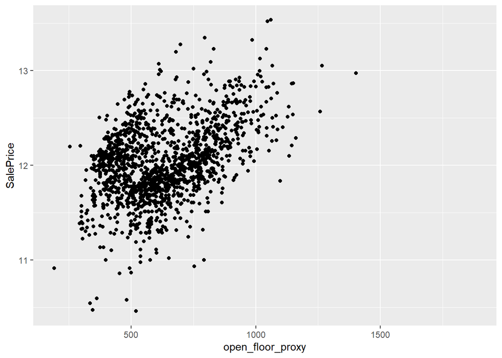

```r
df <- df %>%
  dplyr::mutate(open_floor_proxy = X1stFlrSF/log(TotRmsAbvGrd))
ggplot(df) +
  geom_point(aes(x = open_floor_proxy, y = SalePrice))
```

## Total number of bathrooms (zillow search feature :))

As a home buyer I know the total number of bathrooms is important especially for families.

```r
df <- df %>%
  dplyr::mutate(BathTotal= FullBath + BsmtFullBath + (1/2)*HalfBath + (1/2)*BsmtHalfBath)
```

## Quality materials that are in good condition!

As a home buyer I’m familiar with old homes (like one I am in the middle of purchasing) with quality materials not selling very well due to the condition. Wood floors that need to be refinished can dramatically decrease sale value! Let’s express this with a new feature.

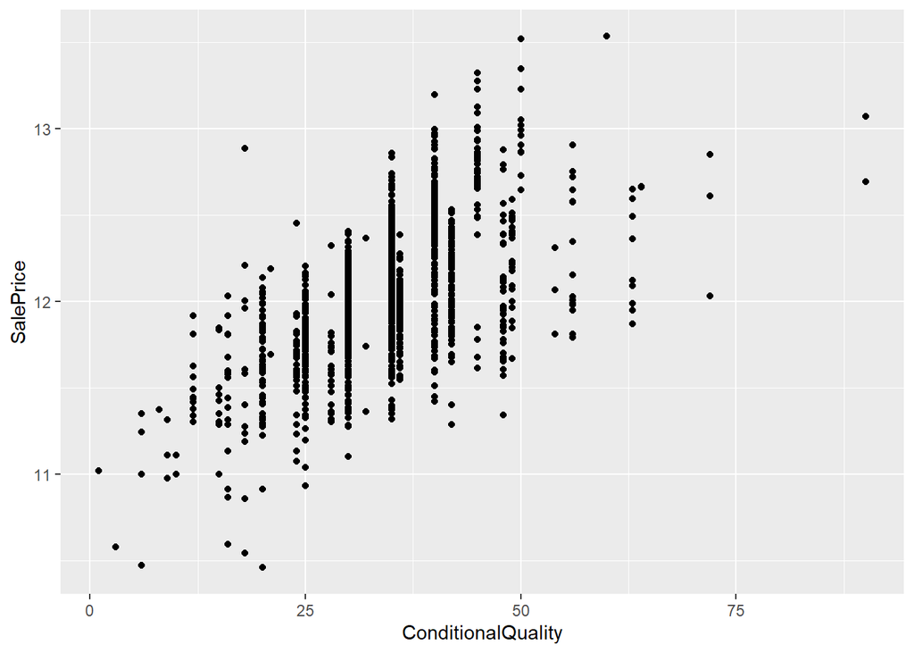

```r
df <- df %>%
  dplyr::mutate(ConditionalQuality = OverallQual*OverallCond)
ggplot(df) +
  geom_point(aes(x = ConditionalQuality, y = SalePrice))
```

## Keeping up with the Jones!

The value of the size of the lot depends greatly on its location. e.g. a large lot near a city or in a wealthy neighborhood is going to cost more. This may not be useful within this dataset if this dataset is all contained within a town! I think this is a variable that would be useful with a larger dataset. Lets give it a try! We are hacking up a neighborhood specific esque lot size variable. Compare your lot to your neighbors lot. Mixed effects may be more useful here but we won’t be experimenting with those models today.

```r
quants <- df %>%
  dplyr::group_by(Neighborhood) %>%
  dplyr::summarise(zone_quant = quantile(LotArea, c(0, .25, 0.5, .75, 1)))
```

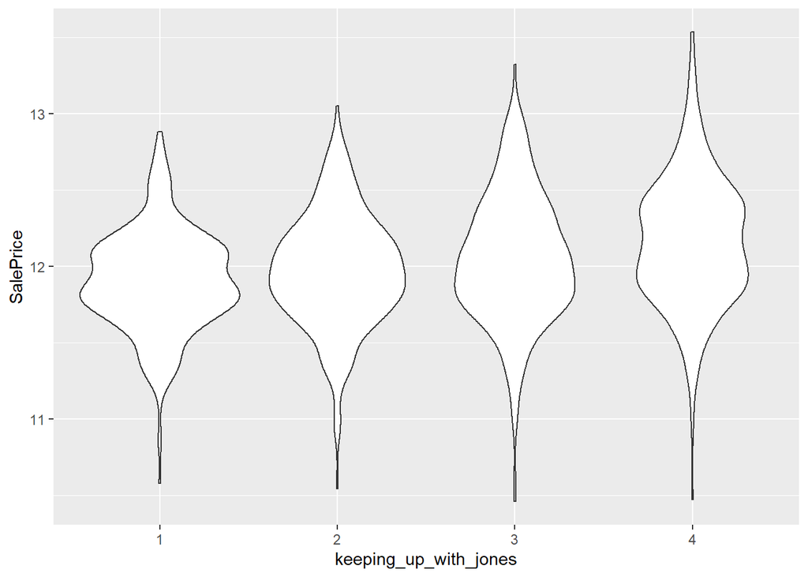

```r
nnames <- unique(df$Neighborhood)
neighborhood_specific_quantile <- list()

for(name in nnames){
  neighborhood_specific_quantile[[name]] <-  quants %>%
  dplyr::filter(Neighborhood == name) %>%
  dplyr::pull(zone_quant)
  neighborhood_specific_quantile[[name]][1] <- 0
}

df <- df %>%
  dplyr::rowwise() %>%
  dplyr::mutate(keeping_up_with_jones =
                  as.factor(
                    cut(LotArea,
                        breaks = neighborhood_specific_quantile[[as.character(Neighborhood)]],
                        labels = c(1,2,3,4),
                        include.lowest=TRUE,
                        )
                    )
                )


ggplot(df) +
  geom_violin(aes(x = keeping_up_with_jones, y = SalePrice))
```

## Eggplant

I’m going all out on my basement theory here. I think the proportion of the total SF which is in the basement impacts the home price. e.g. a one story home with all its SF in the basement.

First Making indicators for basement and garage then overwriting zeros with 1s such that I can work with log

```r
df <- df %>%
  dplyr::mutate(has_basement = ifelse(TotalBsmtSF!=0,1,0)) %>%
  dplyr::mutate(has_garage = ifelse(GarageArea !=0,1,0)) %>%
  dplyr::mutate(GarageArea2 = ifelse(GarageArea ==0, 1, GarageArea)) %>%
  dplyr::mutate(TotalBsmtSF2 = ifelse(TotalBsmtSF == 0, 1, TotalBsmtSF))
```

Imputing the row without basement with mean for the Eggplant variable.

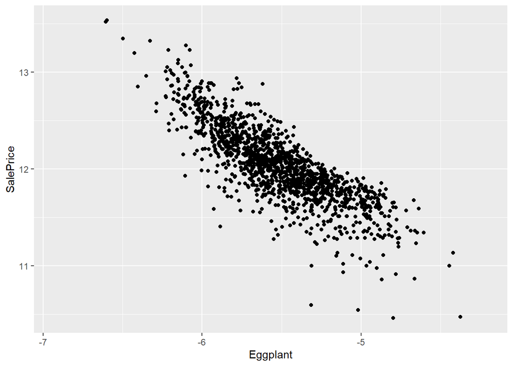

```r
df <- df  %>%
  dplyr::mutate(Eggplant = (log(log(TotalBsmtSF2)/LiveableModSF))) %>%
  dplyr::mutate(Eggplant = ifelse(!is.finite(Eggplant), NA, Eggplant)) %>%
  dplyr::mutate(Eggplant = ifelse(is.na(Eggplant), mean(Eggplant, na.rm=TRUE), Eggplant))

ggplot(df) +
  geom_point(aes(x = Eggplant, y = SalePrice))
```

```r
# hack to fix my dplyr mistake above
df$Eggplant[which(is.na(df$Eggplant))] <- mean(df$Eggplant, na.rm = TRUE)
```

# Modeling fitting

## Feature selection

First we will remove variables which we our intuition tells us will not be useful due to redundant information, extremely low correlation, or sample size too small.

Next we will let feature importance across multiple models decide which features we keep. (top half of variables ranked)

We will not transform some of the continuous variables with zeros e.g. garage and basement as it will create even more distance between the meaningful zeros and the other values.

```r
# transforming continuous feature
df <- df %>%
  dplyr::mutate(LiveableModSF = log(LiveableModSF),
                GrLivArea = log(GrLivArea))

# turning categories that were numeric into factors
df <- df %>%
  dplyr::mutate(YrSold = as.factor(as.character(YrSold))) %>%
  dplyr::mutate(MSSubClass = as.factor(as.character(MSSubClass)))
```

```r
# install.packages("drat", repos="https://cran.rstudio.com")
# drat:::addRepo("dmlc")
# install.packages("xgboost", repos="http://dmlc.ml/drat/", type = "source")
x <- list(
"xgboost",
"randomForest",
"gbm",
"earth")
lapply(x, require, character.only = TRUE)
```

```
## [[1]]
## [1] TRUE
##
## [[2]]
## [1] TRUE
##
## [[3]]
## [1] TRUE
##
## [[4]]
## [1] TRUE
```

```r
toremove <-
  c(
    "LandContour",
    "LotConfig",
    "LandSlope",
    "LotShape",
    "Condition2",
    "BldgType",
    "HouseStyle",
    "RoofStyle",
    "MasVnrType",
    "Exterior2nd",
    "Exterior1st",
    "BsmtFinType2",
    "BsmtFinSF2",
    "BsmtFinSF1",
    "BsmtFullBath",
    "BsmtHalfBath",
    "FullBath",
    "BedroomAbvGr",
    "KitchenAbvGr",
    "GarageYrBlt",
    "GarageFinish",
    "WoodDeckSF",
    "Fence",
    "PoolArea",
    "ScreenPorch",
    "HeatingQC",
    "Neighborhood"
  )
dfmodel <- df %>%
  dplyr::select(-toremove)
```

```
## Note: Using an external vector in selections is ambiguous.
## i Use `all_of(toremove)` instead of `toremove` to silence this message.
## i See <https://tidyselect.r-lib.org/reference/faq-external-vector.html>.
```

```r
# one hot encode
nomvars <- names(dfmodel)[sapply(dfmodel, class) %in% c('factor',"character")]
df2 <- dfmodel %>%
  dplyr::mutate_at(nomvars, as.factor)%>%
  dplyr::select(nomvars) %>%
  dplyr::select(-set)
dummy <- dummyVars(" ~ .", data=df2, fullRank = FALSE)
df2 <- data.frame(predict(dummy, newdata = df2))
dffinal <- cbind(df2, dfmodel %>% dplyr::select(-nomvars))
dffinal$set <- df$set


data <- dffinal %>%
  dplyr::filter(set == "train") %>%
  dplyr::select(-set) %>%
  dplyr::select(-Id)
outcome <- data$SalePrice
data <- data %>%
  dplyr::select(-SalePrice)




library(SuperLearner)
listWrappers()
```

```
## All prediction algorithm wrappers in SuperLearner:
```

[output not shown]

```
##
## All screening algorithm wrappers in SuperLearner:
```

```
## [1] "All"
## [1] "screen.corP"           "screen.corRank"        "screen.glmnet"
## [4] "screen.randomForest"   "screen.SIS"            "screen.template"
## [7] "screen.ttest"          "write.screen.template"
```

```r
# I know these model types are robust to multicolinearity
learners <- c("SL.xgboost", "SL.glmnet")

# Stack models
set.seed(840) # for reproducibility

sl <- CV.SuperLearner(Y = outcome, X = data, SL.library = learners,
                   cvControl =list(V = 5), innerCvControl = list(list(V=5)))
summary(sl)
```

```
##
## Call:
## CV.SuperLearner(Y = outcome, X = data, SL.library = learners, cvControl = list(V = 5),
##     innerCvControl = list(list(V = 5)))
##
## Risk is based on: Mean Squared Error
##
## All risk estimates are based on V =  5
##
##       Algorithm      Ave        se      Min      Max
##   Super Learner 0.012678 0.0010271 0.010733 0.016164
##     Discrete SL 0.013544 0.0010492 0.011460 0.017517
##  SL.xgboost_All 0.014529 0.0011102 0.012580 0.016766
##   SL.glmnet_All 0.013544 0.0010492 0.011460 0.017517
```

```r
ctrl <- SuperLearner.CV.control(V = 5L, shuffle = TRUE)
sl <- SuperLearner(Y = outcome, X = data, SL.library = learners, verbose = TRUE,
                   cvControl = ctrl)
```

```
## Number of covariates in All is: 163
## CV SL.xgboost_All
## CV SL.glmnet_All
## Number of covariates in All is: 163
## CV SL.xgboost_All
## CV SL.glmnet_All
## Number of covariates in All is: 163
## CV SL.xgboost_All
## CV SL.glmnet_All
## Number of covariates in All is: 163
## CV SL.xgboost_All
## CV SL.glmnet_All
## Number of covariates in All is: 163
## CV SL.xgboost_All
## CV SL.glmnet_All
## Non-Negative least squares convergence: TRUE
## full SL.xgboost_All
## full SL.glmnet_All
```

```r
imp_fun <- function(object, newdata) { # for permutation-based VI scores
predict(object, newdata = newdata)$pred
}
par_fun <- function(object, newdata) { # for PDPs
mean(predict(object, newdata = newdata)$pred)
}
library(doParallel) # load the parallel backend
```

```r
cl <- makeCluster(5) # use 5 workers
registerDoParallel(cl)

var_imp <- vip::vi(sl, method = "permute", train = data, target = outcome, metric = "rmse",
              pred_wrapper = imp_fun, nsim = 5, parallel = TRUE)
# Add sparkline representation of feature effects (# Figure 19)
vip::add_sparklines(var_imp[1L:15L, ], fit = sl, pred.fun = par_fun, train = data,
digits = 2, verbose = TRUE, trim.outliers = TRUE,
grid.resolution = 20, parallel = TRUE)
```

```
## Computing partial dependence...
##   LiveableModSF
##   TotalBsmtSF
##   OverallQual
##   ConditionalQuality
##   GrLivArea
##   Age
##   X2ndFlrSF
##   LotArea
##   X1stFlrSF
##   GarageArea
##   OverallCond
##   SaleCondition.Abnorml
##   BsmtUnfSF
##   YearBuilt
##   BathTotal
```

|  | Variable | Importance | StDev | Effect |
| --- | --- | --- | --- | --- |
| 1 | LiveableModSF | 0.08 | 0.00 | 11.8452791203561,11.856150640654,11.8869664759604,11.8852227217162,11.9172445826518,11.9195199476581,11.9384310567292,11.9589394516955,11.9769829698379,12.0076849048417,12.0345555819414,12.04208305743… |
| 2 | TotalBsmtSF | 0.03 | 0.00 | 11.9162133358051,11.9239424807443,11.930802567337,11.9380236496257,11.944710341611,11.9643828421975,11.9867635607369,11.9975151093913,12.008185856335,12.0216765668821,12.0397004836216,12.046734195277,… |
| 3 | OverallQual | 0.03 | 0.00 | 11.9453065774767,11.9453065774767,11.9453065774767,11.9585264762806,11.9585264762806,11.9721561124805,11.9721561124805,11.9721561124805,11.9836234969007,11.9836234969007,12.0061606559769,12.0061606559… |
| 4 | ConditionalQuality | 0.03 | 0.00 | 11.9180076920245,11.9349378020946,11.9631374070155,11.9657218362119,11.9728829562094,11.9946591145563,11.9996181739393,12.0149141996548,12.0192731137813,12.0232687677911,12.0276401893453,12.0358055604… |
| 5 | GrLivArea | 0.02 | 0.00 | 11.9397298481202,11.9525495651564,11.9579715064956,11.9671521129671,11.9729380110998,11.9840017159098,11.9927312647663,12.0081734810745,12.0161687913693,12.0188619021536,12.0366303471721,12.0380296572… |
| 6 | Age | 0.02 | 0.00 | 12.0668727779162,12.0494093884296,12.0464672379284,12.0382580971001,12.0325266308706,12.0254038979576,12.0206068295592,12.0155659883342,12.0109123884353,12.0043636938349,11.9951439754478,11.9901394230… |
| 7 | X2ndFlrSF | 0.01 | 0.00 | 12.0015128232528,12.0067992370853,12.0128286628485,12.0186862068639,12.0242787149605,12.0318171584728,12.0352174864528,12.0430961963632,12.0536826348342,12.0589009999255,12.0669947645911,12.0722041395… |
| 8 | LotArea | 0.01 | 0.00 | 11.9816812564942,11.9830110715458,11.9863930079779,11.9978569112531,12.0017551358168,12.0050463759145,12.0111168811237,12.01879261296,12.0178831956653,12.0196880268117,12.0199316873345,12.026671481122… |
| 9 | X1stFlrSF | 0.01 | 0.00 | 11.9650268664231,11.9689851656242,11.9746444366546,11.9814774793352,11.9948191865253,12.0096878524397,12.0159221644628,12.0155105061523,12.0183793254078,12.0225719086614,12.0269928531664,12.0319139130… |
| 10 | GarageArea | 0.01 | 0.00 | 11.9966257194965,11.9976711592242,11.9987165989519,11.9997620386796,12.0078749351647,12.0167263872238,12.0203089970441,12.0207875717718,12.0201337384085,12.0235257370601,12.0218198970716,12.0194956840… |

[output cut: 5 more lines]

Feature selection based on importance.

```r
varvec <- var_imp$Variable
varvec <- gsub("\\..*","",varvec)
varvecun <- unique(varvec)
varvecun_short <- varvecun[1:round(length(varvecun)/2)]
dfmodel <- df %>%
  dplyr::select(varvecun_short)
```

## Final model

I lack experience tuning specific ML - for simplicity using default settings. Future work would be tuning.

```r
nomvars <- names(dfmodel)[sapply(dfmodel, class) %in% c('factor',"character")]
dffinal <- dfmodel %>%
  dplyr::mutate_at(nomvars, as.factor)


#  one hot encode
df2 <- dffinal %>%
  dplyr::select(nomvars)
dummy <- dummyVars(" ~ .", data=df2, fullRank = FALSE)
df2 <- data.frame(predict(dummy, newdata = df2))
dffinal <- cbind(df2, dffinal %>% dplyr::select(-nomvars))
dffinal$set <- df$set

data <- dffinal %>%
  dplyr::filter(set == "train") %>%
  dplyr::select(-set)
outcome <- df %>%
  dplyr::filter(set == "train")%>%
  dplyr::pull(SalePrice)


data_test <- dffinal %>%
  dplyr::filter(set == "test") %>%
  dplyr::select(-set)



SuperLearner::listWrappers()

learners <- list("SL.lm", "SL.xgboost", "SL.earth", c("SL.glmnet","screen.glmnet"),  "SL.randomForest")

# Stack models
set.seed(840) # for reproducibility
sl <- SuperLearner::SuperLearner(Y = outcome, X = data,
  SL.library = learners)
sl

pred <- predict(sl, data_test, onlySL = TRUE)
final <- data.frame(Id = df %>% dplyr::filter(set == "test") %>% dplyr::pull(Id), SalePrice = exp(pred$pred))
write.csv(final, row.names = FALSE, "predictions.csv")
```

## Future work

catboost, tuning, time series analysis, mixed modeling